# Exceptions

Explaining and giving examples how to handle exceptions in the Python programming language.

- Exceptions: What are they?
- Try statement defined
- Try statement
- Try Statement Syntax
- How to handle a ValueError exception
- How to handle ALL exceptions
- Resources

## Exceptions: What are they?

- When an error happens in our code, it is called an exception.
- Python will normally stop and generate (throw) an error message to the console.
- 'Try' statements are used to handle exceptions.
- This makes it possible to code for most common user input errors.

## Try Statement Defined

- In a try statement, you code any statements that may throw an exception in the try clause. Then, you can code an except clause that handles any exception that occurs.
- If you don't code the name of an exception type in the except clause, the except clause handles all types of exceptions that can occur.
- When an exception occurs, Python skips any remainng statements in the try clause and executes the statements in the except clause
- This is known as exception handling

## Try Statement

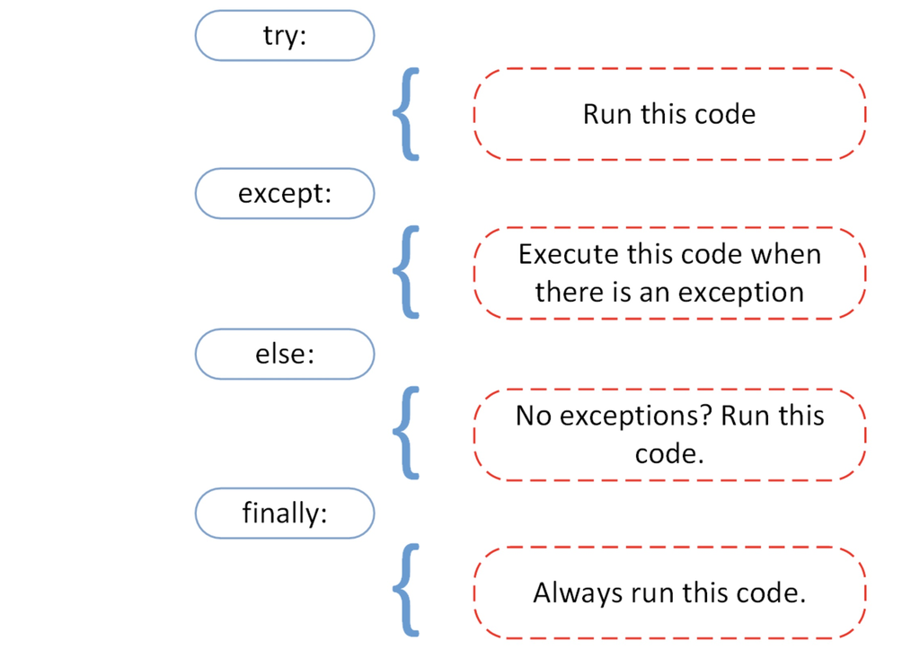

## Try statement syntax

#### This try statement catches an exception.

```python
try:
    statements
except [ExceptionName]:
    statements
```

## How to handle a ValueError exception

#### In this example we enter the value 55.

```python
try:
    number = int(input("Enter a number between 1 and 100: "))
    print("You entered a valid number of " + str(number) + ".")
except ValueError:
    print("You entered an invalid integer. Please try again.")
print("Thanks")
```

```
Enter a number between 1 and 100: 55
You entered a valid number of 55.
Thanks
```

#### In this example we enter the value Five. Notice how the print function in the except ValueError is executed.

```python
try:
    number = int(input("Enter a number between 1 and 100: "))
    print("You entered a valid number of " + str(number) + ".")
except ValueError:
    print("You entered an invalid integer. Please try again.")
print("Thanks")
```

```
Enter a number between 1 and 100: Five
You entered an invalid integer. Please try again.
Thanks
```

## How to handle ALL exceptions

#### Example of NO exception being thrown

```python
try:
    numMiles = int(input("Enter miles driven: "))
    numGallons = int(input("Enter amount of gas used: "))
    print("You traveled " + str(numMiles) + " and used " + str(numGallons) + " gallons of gas.")
except :
    print("You entered an invalid integer. Please try again.")
print("Thanks")
```

```
Enter miles driven: 150
Enter amount of gas used: 15
You traveled 150 and used 15 gallons of gas.
Thanks
```

#### Example of an exception being thrown!

```python
try:
    numMiles = int(input("Enter miles driven: "))
    numGallons = int(input("Enter amount of gas used: "))
    print("You traveled " + str(numMiles) + " and used " + str(numGallons) + " gallons of gas.")
except :
    print("You entered an invalid integer. Please try again.")
print("Thanks")
```

```
Enter miles driven: 150
Enter amount of gas used: ten
You entered an invalid integer. Please try again.
Thanks
```

## Resources

#### Sources and deeper learning research:

1. Python Programming-Beginner to Pro.Michael Urban,Joel Murach.Murach Press.2016.ISBN:978-1-890774-97-4.www.murach.com.
1. W3Schools.com - [Python Try Except](https://www.w3schools.com/python/python_try_except.asp)